# Lab 10 - Trees, Bagging, Random Forest

```r
knitr::opts_chunk$set(eval = F, include  = T)
```

# Learning goals

- Perform classification and regression with tree-based methods in R
- Recognize that tree-based methods are capable of capturing non-linearities by splitting multiple times on the same variables
- Compare the performance of classification trees, bagging,and random forests for predicting heart disease based on the `heart` data.

# Lab description

For this lab we will be working with simulated data and the `heart` dataset that you can download from [here](https://github.com/JSC370/jsc370-2022/blob/main/data/heart/heart.csv)

### Setup packages

You should install and load `rpart` (trees), `randomForest` (random forest), `gbm` (gradient boosting) and `xgboost` (extreme gradient boosting).

```r
install.packages(c("rpart","randomForest","gbm","xgboost"))
```

### Load packages and data

```
##   Age Sex    ChestPain RestBP Chol Fbs RestECG MaxHR ExAng Oldpeak Slope Ca
## 1  63   1      typical    145  233   1       2   150     0     2.3     3  0
## 2  67   1 asymptomatic    160  286   0       2   108     1     1.5     2  3
## 3  67   1 asymptomatic    120  229   0       2   129     1     2.6     2  2
## 4  37   1   nonanginal    130  250   0       0   187     0     3.5     3  0
## 5  41   0   nontypical    130  204   0       2   172     0     1.4     1  0
## 6  56   1   nontypical    120  236   0       0   178     0     0.8     1  0
##         Thal AHD
## 1      fixed  No
## 2     normal Yes
## 3 reversable Yes
## 4     normal  No
## 5     normal  No
## 6     normal  No
```

## Question 1: Trees with simulated data

- Simulate data from a random uniform distribution [-5,5] and normally distributed errors (s.d = 0.5)
- Create a non-linear relationship y=sin(x)+error
- Split the data into test and training sets (500 points each), plot the data

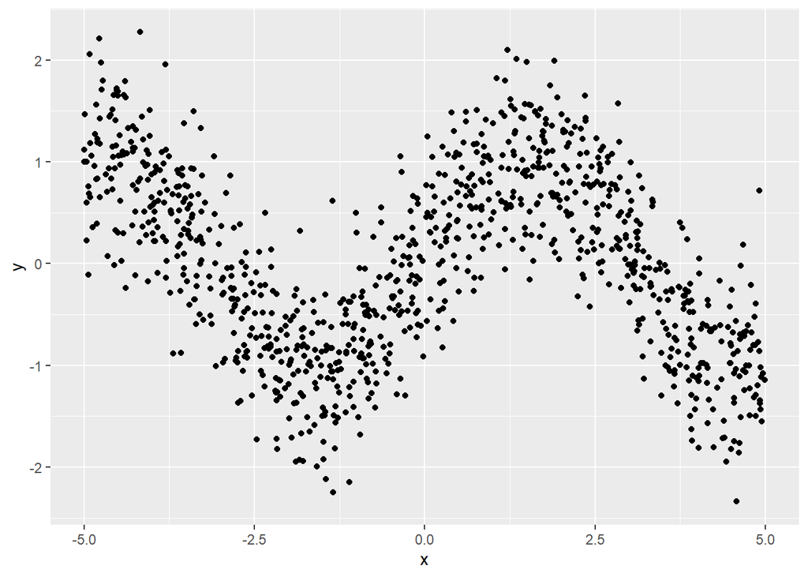

- Fit a regression tree using the training set, plot it

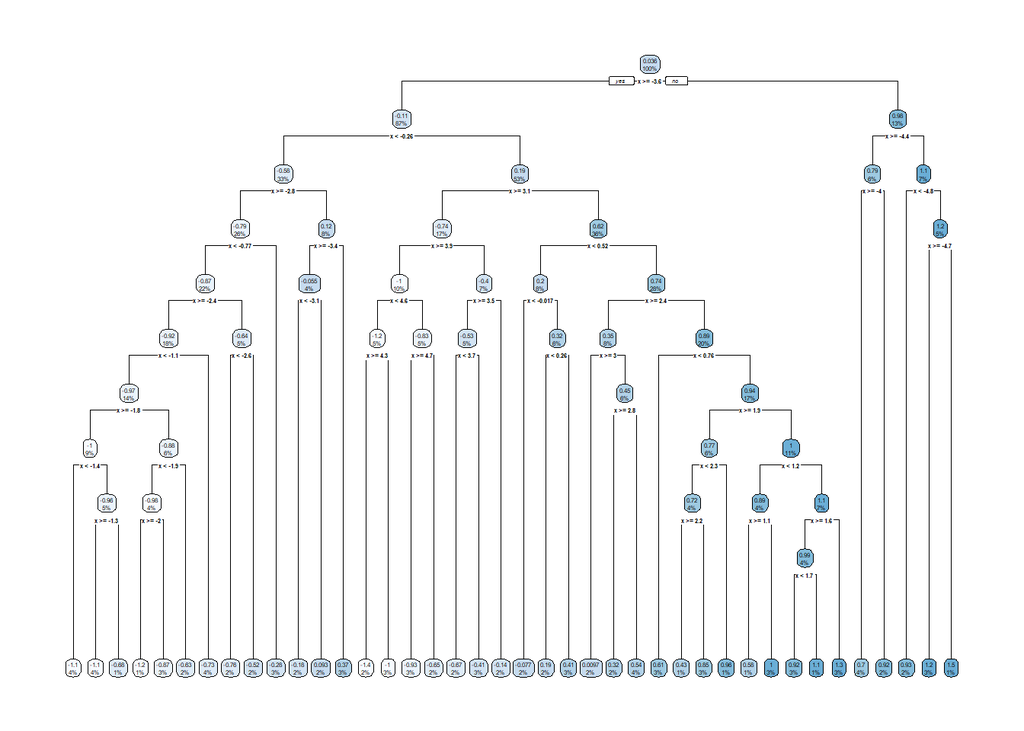

- Determine the optimal complexity parameter (cp) to prune the tree

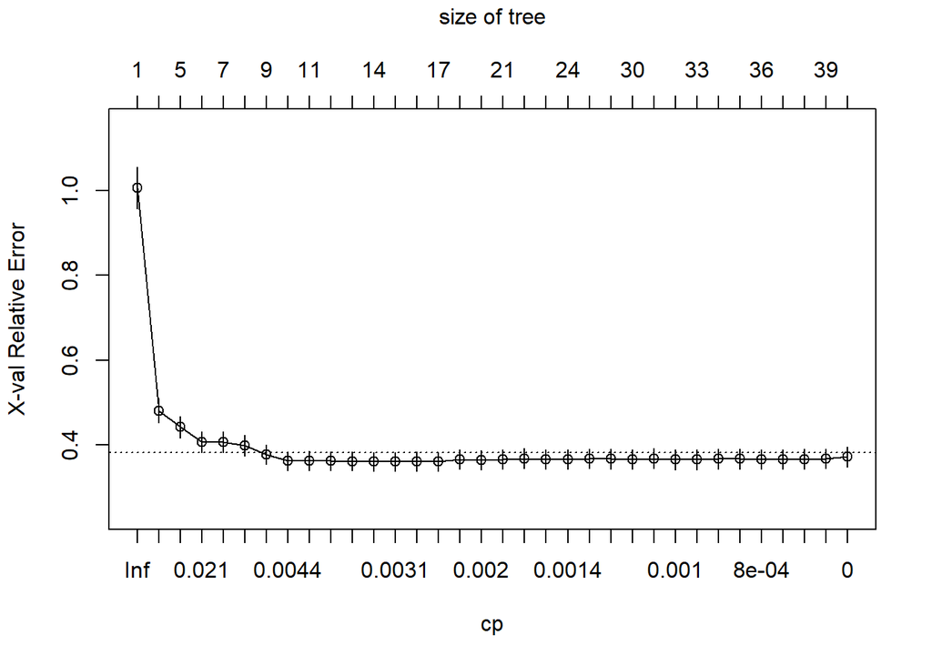

```
##
## Regression tree:
## rpart(formula = y ~ x, data = nonlin_train, method = "anova",
##     control = list(cp = 0))
##
## Variables actually used in tree construction:
## [1] x
##
## Root node error: 422.97/500 = 0.84594
##
## n= 500
##
##            CP nsplit rel error  xerror     xstd
## 1  0.18580228      0   1.00000 1.00683 0.048942
## 2  0.05779750      3   0.44259 0.48080 0.028909
```

[output cut: 32 more lines]

- Prune and plot the tree and summarize

```
## Call:
## rpart(formula = y ~ x, data = nonlin_train, method = "anova",
##     control = list(cp = 0))
##   n= 500
##
##             CP nsplit rel error    xerror       xstd
## 1  0.185802277      0 1.0000000 1.0068285 0.04894211
## 2  0.057797505      3 0.4425932 0.4808048 0.02890888
## 3  0.021836224      4 0.3847957 0.4416499 0.02574813
## 4  0.019588688      5 0.3629594 0.4065695 0.02422297
## 5  0.017590500      6 0.3433708 0.4071508 0.02460444
## 6  0.012105362      7 0.3257803 0.3987294 0.02430723
## 7  0.004843282      8 0.3136749 0.3776220 0.02294567
## 8  0.003989663      9 0.3088316 0.3620227 0.02219369
## 9  0.003681589     10 0.3048419 0.3622030 0.02230825
## 10 0.003392297     11 0.3011604 0.3622295 0.02219868
## 11 0.003196679     12 0.2977681 0.3608748 0.02201608
## 12 0.003131237     13 0.2945714 0.3606289 0.02201277
## 13 0.002992572     14 0.2914401 0.3599857 0.02209806
## 14 0.002934114     15 0.2884476 0.3606611 0.02221482
## 15 0.002876640     16 0.2855135 0.3603440 0.02219393
##
## Variable importance
##   x
## 100
##
## Node number 1: 500 observations,    complexity param=0.1858023
##   mean=0.03569068, MSE=0.8459433
##   left son=2 (434 obs) right son=3 (66 obs)
##   Primary splits:
##       x < -3.596879   to the right, improve=0.1608823, (0 missing)
##
## Node number 2: 434 observations,    complexity param=0.1858023
##   mean=-0.1081732, MSE=0.7733648
##   left son=4 (167 obs) right son=5 (267 obs)
##   Primary splits:
##       x < -0.2633661  to the left,  improve=0.1805095, (0 missing)
##
## Node number 3: 66 observations,    complexity param=0.004843282
##   mean=0.9817048, MSE=0.2921618
```

[output cut: 117 more lines]

```
##
## Node number 94: 16 observations
##   mean=0.6051192, MSE=0.1967851
##
## Node number 95: 86 observations,    complexity param=0.002992572
##   mean=0.9448728, MSE=0.2509512
##   left son=190 (29 obs) right son=191 (57 obs)
##   Primary splits:
##       x < 1.876751    to the right, improve=0.05865001, (0 missing)
##
## Node number 190: 29 observations
##   mean=0.7747874, MSE=0.2560542
##
## Node number 191: 57 observations
##   mean=1.031408, MSE=0.2261484
```

- Based on the plot and/or summary of the pruned tree create a vector of the (ordered) split points for variable x, and a vector of fitted values for the intervals determined by the split points of x.
- plot the step function corresponding to the fitted (pruned) tree

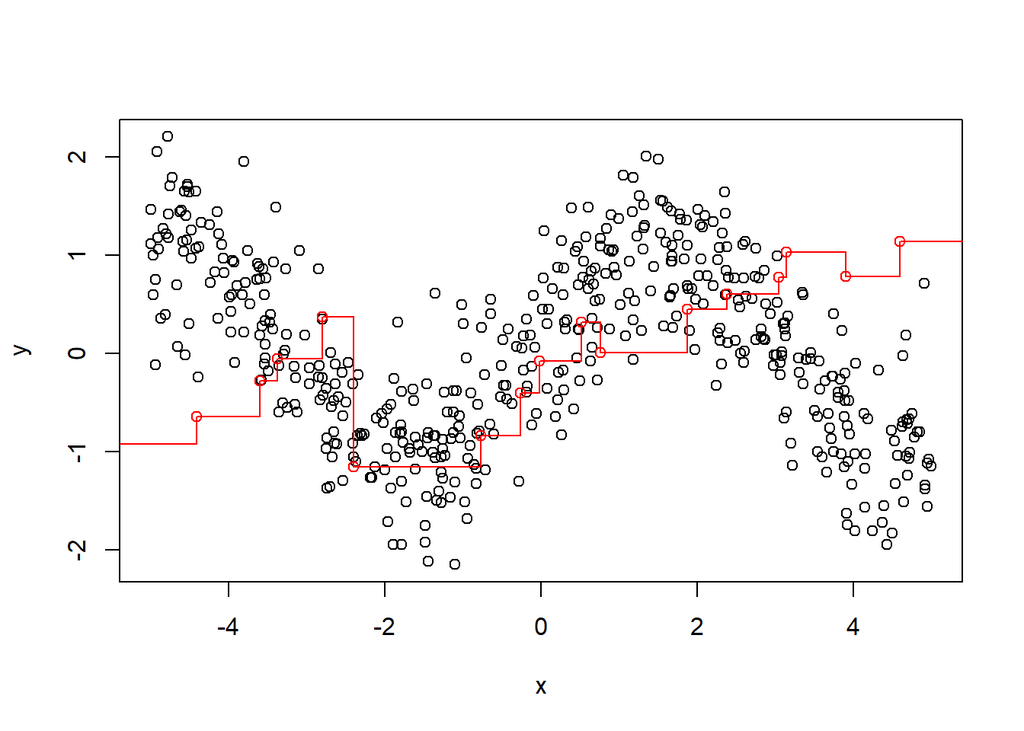

- Fit a linear model to the training data and plot the regression line.
- Contrast the quality of the fit of the tree model vs. linear regression by inspection of the plot
- Compute the test MSE of the pruned tree and the linear regression model

```
##
## Call:
## lm(formula = y ~ x, data = nonlin_train)
##
## Residuals:
##      Min       1Q   Median       3Q      Max
## -2.24505 -0.72502  0.03393  0.70681  2.04876
##
## Coefficients:
##             Estimate Std. Error t value Pr(>|t|)
## (Intercept)  0.03536    0.04057   0.872    0.384
## x           -0.05674    0.01421  -3.992 7.53e-05 ***
## ---
## Signif. codes:  0 '***' 0.001 '**' 0.01 '*' 0.05 '.' 0.1 ' ' 1
##
## Residual standard error: 0.9072 on 498 degrees of freedom
## Multiple R-squared:  0.03101,    Adjusted R-squared:  0.02907
## F-statistic: 15.94 on 1 and 498 DF,  p-value: 7.53e-05
```

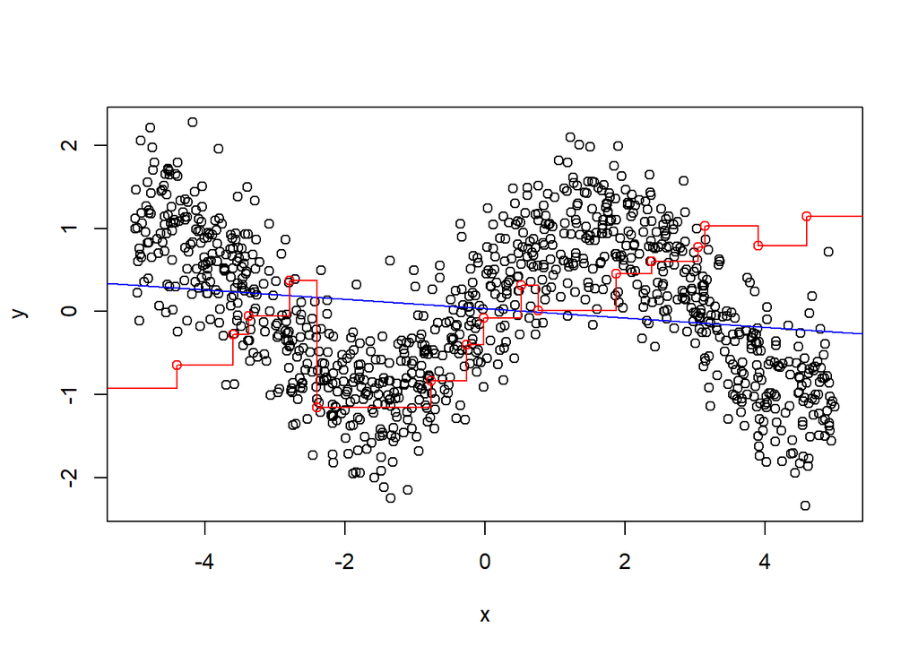

```
## [1] 0.2741518
```

```
## [1] 0.7558272
```

- Is the lm or regression tree better at fitting a non-linear function? The regression tree MSE is less than that of lm’s and the regression tree fits the non-linear function better.

## Question 2: Analysis of Real Data

- Split the `heart` data into training and testing (70-30%)
- Fit a classification tree using rpart, plot the full tree

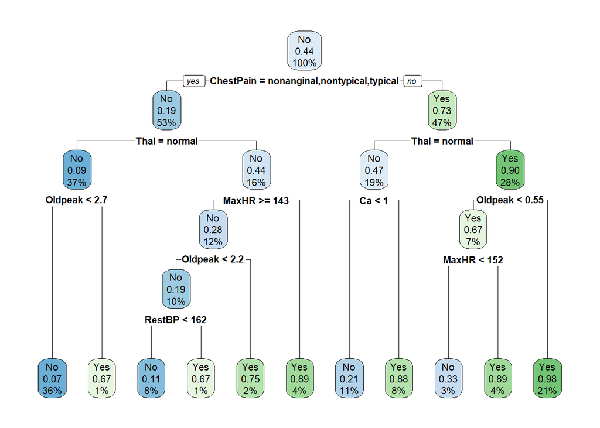

- Plot the complexity parameter table for an rpart fit and prune the tree

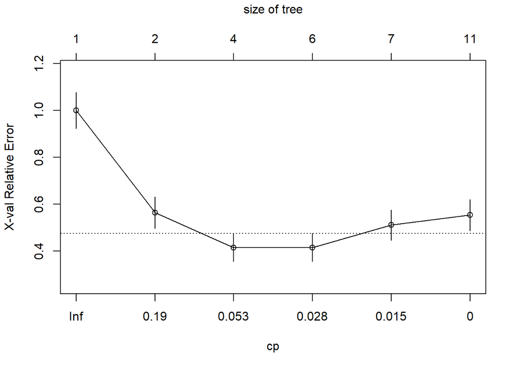

```
##
## Classification tree:
## rpart(formula = AHD ~ ., data = train, method = "class", control = list(minsplit = 10,
##     minbucket = 3, cp = 0, xval = 10))
##
## Variables actually used in tree construction:
## [1] Ca        ChestPain MaxHR     Oldpeak   RestBP    Thal
##
## Root node error: 94/212 = 0.4434
##
## n= 212
##
##         CP nsplit rel error  xerror     xstd
## 1 0.478723      0   1.00000 1.00000 0.076950
## 2 0.074468      1   0.52128 0.56383 0.067072
## 3 0.037234      3   0.37234 0.41489 0.060015
## 4 0.021277      5   0.29787 0.41489 0.060015
## 5 0.010638      6   0.27660 0.51064 0.064826
## 6 0.000000     10   0.23404 0.55319 0.066645
```

```
## [1] 0.03723404
```

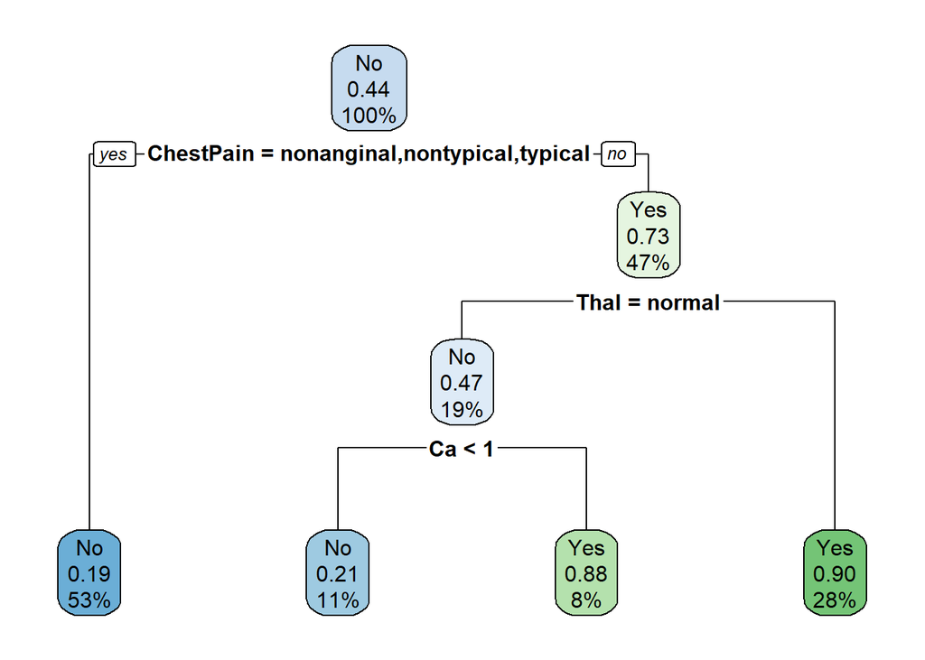

```
##      predicted
## true  no yes
##   No  41   5
##   Yes 14  31
```

- Compute the test misclassification error

```
## [1] 0.2087912
```

- Fit the tree with the optimal complexity parameter to the full data (training + testing)

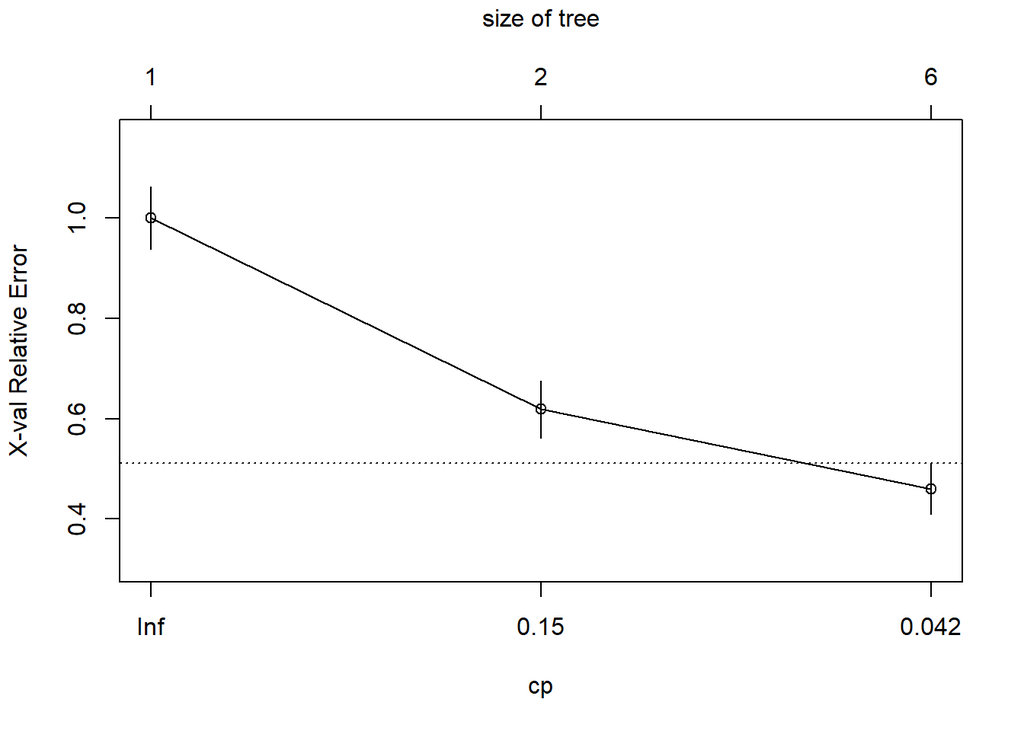

- Out of Bag (OOB) error for tree

```
##           CP nsplit rel error    xerror       xstd
## 1 0.47482014      0 1.0000000 1.0000000 0.06240124
## 2 0.04676259      1 0.5251799 0.6187050 0.05646027
## 3 0.03723404      5 0.3381295 0.4604317 0.05111552
```

```
## [1] 139.5108
```